# R HW 05: Women’s Soccer

Author

Robsen Gelalcha

Published

October 3, 2026

```r
library(tidyverse)
library(viridis)
library(kableExtra)
library(ggridges)
library(devtools)
library(nwslR)
library(gt)

matches <- load_matches()
players <- load_players()
teams   <- load_teams()
metrics <- load_metrics()
```

# Exercise 1

```r
#determines the external_team_id for the Portland Thorns, 8.
teams |>
  filter(team_name == "Portland Thorns FC") |>
    select(external_team_id)
```

```
# A tibble: 1 × 1
  external_team_id
             <dbl>
1                8
```

```r
portland_matches <- matches |>
  filter(home_team_id == 8 | away_team_id == 8)
```

# Exercise 2

```r
home_team_info <- teams |>
  select(home_team_id = external_team_id,
         home_team_name = team_name,
         home_team_abbr = team_abbreviation)


portland_matches <- portland_matches |>
  left_join(home_team_info)
dim(portland_matches)
```

```
[1] 223  17
```

```r
away_team_info <- teams |>
  select (away_team_id = external_team_id,
          away_team_name = team_name,
          away_team_abbr = team_abbreviation)

portland_matches <- portland_matches |>
  left_join(away_team_info)
dim(portland_matches)
```

```
[1] 223  19
```

# Exercise 3

```r
portland_matches <- portland_matches |>
  mutate(POR_points = if_else(home_team_abbr == "POR",
                              home_team_score, away_team_score),
         OPP_points = if_else(home_team_abbr != "POR",
                              home_team_score, away_team_score),
         result = case_when(POR_points > OPP_points ~ "Win",
                            POR_points < OPP_points ~ "Loss",
                            POR_points == OPP_points ~ "Tie"))
```

# Exercise 4

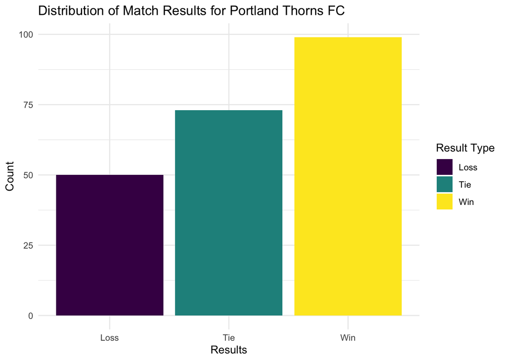

```r
# Create a bar chart showing the distribution of result.
# Include clear axis labels and a title.
# Interpret the results.

portland_matches |>
  filter(!is.na(result)) |>
  ggplot(aes(x = result, fill = result)) +
  geom_bar() +
  scale_fill_viridis_d(option = "viridis") +
  theme_minimal() +
  labs (
    title = "Distribution of Match Results for Portland Thorns FC",
    x = "Results",
    y = "Count",
    fill = "Result Type"
  )
```

# Exercise 5

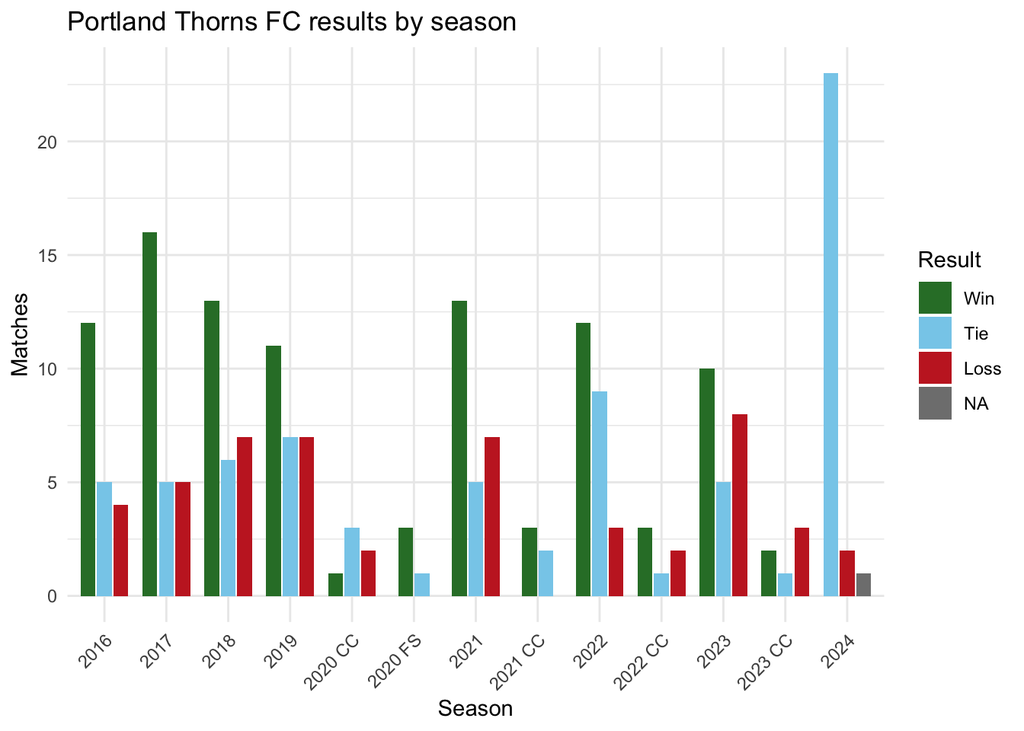

```r
# Create a visualization examining Portland’s performance by season (wins, losses, and ties).
#
# Describe 2–3 patterns you observe.

# glimpse(portland_matches)

portland_matches |>
  mutate(
    season = str_replace(season, regex("Challenge Cup", ignore_case = TRUE), "CC"),
    season = str_replace(season, regex("Fall Series", ignore_case = TRUE), "FS"),
    result = factor(result, levels = c("Win", "Tie", "Loss"))
  ) |>
  ggplot(aes(x = season, fill = result)) +
  geom_bar(position = position_dodge2(preserve = "single"), width = 0.8) +
  scale_fill_manual(values = c(Win = "#2E7D32", Tie = "#87CEEB", Loss = "#C62828")) +
  labs(
    title = "Portland Thorns FC results by season",
    x = "Season", y = "Matches", fill = "Result"
  ) +
  theme_minimal() +
  theme(axis.text.x = element_text(angle = 45, hjust = 1))
```

- Patterns: regular seasons are winning ones; challenge cups are short tournaments; 2024 season is an outlier with 23 ties and no wins, I’m guessing it’s a bunch of placeholder scores of 0 - 0.

# Exercise 6

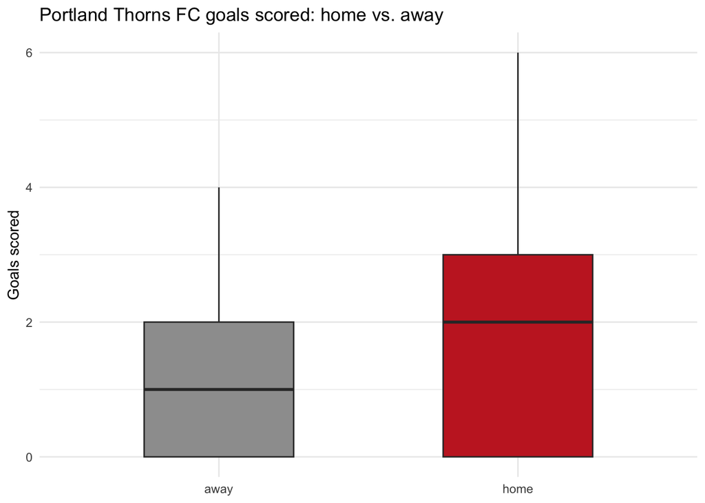

```r
# Does Portland have a home-field advantage?
#
# To investigate this question,
#
#     Create a variable indicating whether Portland was the home or away team
#     Make side-by-side boxplots of points scored
#     Create a ridge plot using geom_density_ridges()
#
# Describe 2–3 observations.

portland_matches <- portland_matches |>
  mutate(
    home_or_away = ifelse(home_team_abbr == "POR", "home", "away")
  )

portland_matches |>
  filter(!is.na(home_or_away)) |>
  ggplot(aes(x = home_or_away, y = POR_points, fill = home_or_away)) +
  geom_boxplot(width = 0.5, outlier.shape = NA) +

  scale_fill_manual(values = c(home = "#C62828", away = "#9E9E9E")) +
  labs(
    title = "Portland Thorns FC goals scored: home vs. away",
    x = NULL, y = "Goals scored"
  ) +
  theme_minimal() +
  theme(legend.position = "none")
```

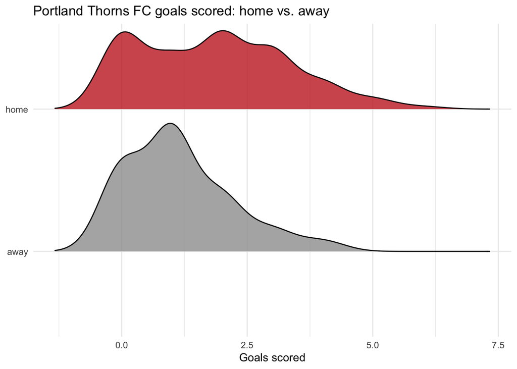

```r
portland_matches |>
  filter(!is.na(home_or_away)) |>
  ggplot(aes(x = POR_points, y = home_or_away, fill = home_or_away)) +
  geom_density_ridges(alpha = 0.8, scale = 0.9) +
  scale_fill_manual(values = c(home = "#C62828", away = "#9E9E9E")) +
  labs(
    title = "Portland Thorns FC goals scored: home vs. away",
    x = "Goals scored", y = NULL
  ) +
  theme_minimal() +
  theme(legend.position = "none")
```

- Portland Thorns clearly enjoy a home advantage. Their highest scoring matches were at home, as indicated by the box plot. And also the games where they scored a goal or less are more concentrated in the away matches.

# Exercise 7

```r
win_summary <- portland_matches |>
  filter(!is.na(home_or_away), !is.na(result)) |>
  group_by(home_or_away) |>
  summarize(
    games = n(),
    wins = sum(result == "Win"),
    prop_won = mean(result == "Win")
  )
glimpse(win_summary)
```

```
Rows: 2
Columns: 4
$ home_or_away <chr> "away", "home"
$ games        <int> 109, 113
$ wins         <int> 36, 63
$ prop_won     <dbl> 0.3302752, 0.5575221
```

```r
win_summary |>
  mutate(home_or_away = str_to_title(home_or_away)) |>
  gt() |>
  tab_header(
    title = "Portland Thorns FC win rate",
    subtitle = "Home vs. awy matches"
  ) |>
  cols_label(
    home_or_away = "Venue",
    games = "Games",
    wins = "Wins",
    prop_won = "Win %"
  ) |>
  fmt_percent(columns = prop_won, decimals = 1)
```

Portland Thorns FC win rate

Home vs. awy matches

| Venue | Games | Wins | Win % |
| --- | --- | --- | --- |
| Away | 109 | 36 | 33.0% |
| Home | 113 | 63 | 55.8% |

# Exercise 8

```r
safe_load_pms <- purrr::possibly(load_player_match_stats,
                                 otherwise = data.frame())

player_stats <- purrr::map_df(portland_matches$match_id,
                              safe_load_pms,
                              .progress = TRUE)
```

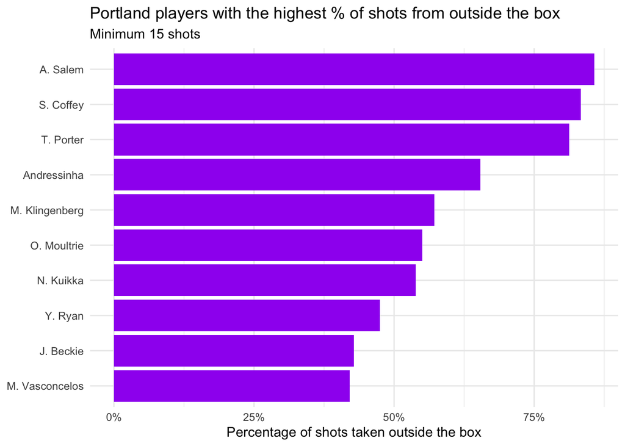

```r
# Load saved version
# avoids lengthy re-loading from package on each Render
player_stats <- readRDS("./data/player_stats.rds")
shooting <- player_stats |>
  filter(team_id == 8) |>
  select(player_id, team_id, shots_total, shots_outside_box, goals) |>
  group_by(player_id) |>
  summarise(shots_total       = sum(shots_total, na.rm = TRUE),
            shots_outside_box = sum(shots_outside_box, na.rm = TRUE),
            goals             = sum(goals, na.rm = TRUE)) |>
  filter(shots_total >= 15) |>
  mutate(prop_outside_box = shots_outside_box / shots_total,
         prop_goals       = goals / shots_total) |>
  left_join(players, by = "player_id")

shooting |>
  slice_max(prop_outside_box, n = 10) |>
  ggplot(aes(x = prop_outside_box,
             y = reorder(player_match_name, prop_outside_box))) +
  geom_col(fill = "purple") +
  scale_x_continuous(labels = scales::percent) +
  theme_minimal() +
  labs(x = "Percentage of shots taken outside the box", y = NULL,
       title = "Portland players with the highest % of shots from outside the box",
       subtitle = "Minimum 15 shots")
```

```r
shooting |>
  slice_max(prop_goals, n = 10) |>
  select(player_match_name, shots_total, goals, prop_goals) |>
  mutate(prop_goals = scales::percent(prop_goals, accuracy = 0.1)) |>
  kable(col.names = c("Player", "Shots", "Goals", "Conversion")) |>
  kable_styling(full_width = FALSE)
```

| Player | Shots | Goals | Conversion |
| --- | --- | --- | --- |
| E. Sonnett | 26 | 8 | 30.8% |
| H. Sugita | 60 | 14 | 23.3% |
| T. Porter | 16 | 3 | 18.8% |
| N. Nadim | 81 | 15 | 18.5% |
| C. Sinclair | 322 | 54 | 16.8% |
| H. Betfort | 30 | 5 | 16.7% |
| D. Brynjarsdóttir | 41 | 6 | 14.6% |
| H. Raso | 97 | 13 | 13.4% |
| A. Long | 63 | 8 | 12.7% |
| M. Purce | 63 | 8 | 12.7% |

# BONUS

## Question: Who scored the most goals per 90 mins. played?

```r
player_stats |>
  filter(team_id == 8) |>
  group_by(player_id) |>
  summarize(minutes = sum(minutes, na.rm = TRUE)
            ,goals = sum(goals, na.rm = TRUE)) |>
  filter(minutes >= 900) |>
  mutate(goals_per_90 = goals / minutes * 90) |>
  left_join(players, by = "player_id") |>
  slice_max(goals_per_90, n = 5) |>
  select(player_match_name, minutes, goals, goals_per_90)
```

```
# A tibble: 5 × 4
  player_match_name minutes goals goals_per_90
  <chr>               <dbl> <dbl>        <dbl>
1 S. Smith             5273    35        0.597
2 N. Nadim             2905    15        0.465
3 H. Betfort           1001     5        0.450
4 C. Sinclair         12213    54        0.398
5 M. Weaver            5420    20        0.332
```

# Reflection prompts

*Respond to each of the following after you have completed all exercises in this assignment*

*(RP1): What were the main concepts / skills covered in this assignment?*

- Different types of joins, in addition to how to use them with data wrangling.

*(RP2): What’s one thing you understand better after completing these exercises?*

- How group_by works.

*(RP3): What exercise(s) gave you the most trouble? What was difficult about them/where did you get stuck?*

- The last question was really dumbfounding for me. I didn’t internalize the workings of the summarize function before trying to tackle the problem.